# R Notebook

## — Exploratory Data Analysis (EDA) —

```r
# Import packages

library(readr)
library(visdat)
library(dplyr)
library(ggplot2)
library(psych)
library(odbc)
library(DBI)
library(dbscan)
library(naniar)
library(cocor)
library(gridExtra)
library(corrgram)
# 'mechkar' - written by Tomas Carpati
source("C:/Users/Avishai/Documents/General/Personal/DS Course/Google drive content/Projects/Final project-ASHRAE-Great Energy Predictor III/Scripts/R/mechkar.R")
source("C:/Users/Avishai/Documents/General/Personal/DS Course/Google drive content/Projects/Final project-ASHRAE-Great Energy Predictor III/Scripts/R/utils.R")
```

Import of ‘ff_train_agg’ dataset from check point 1:

```r
ff_train_agg <- data.frame(read.csv("C:/Users/Avishai/Documents/General/Personal/DS Course/Google drive content/Projects/Final project-ASHRAE-Great Energy Predictor III/Data/CheckPoint1/ff_train_agg.csv"))
ff_train_agg
```

| site_id | building_id | date | time_range_x_mode | time_range_y_mode | meter_reading_sum | precip_depth_sum | precip_depth_min | precip_depth_max | precip_depth_sd | air_temperature_mean | air_temperature_min | air_temperature_max | air_temperature_sd | dew_temperature_mean | dew_temperature_min | dew_temperature_max | dew_temperature_sd | sea_level_pressure_mean | sea_level_pressure_min | sea_level_pressure_max | sea_level_pressure_sd | wind_speed_mean | wind_speed_min | wind_speed_max | wind_speed_sd | rel_humid_mean | rel_humid_min | rel_humid_max | rel_humid_sd | … |
| --- | --- | --- | --- | --- | --- | --- | --- | --- | --- | --- | --- | --- | --- | --- | --- | --- | --- | --- | --- | --- | --- | --- | --- | --- | --- | --- | --- | --- | --- | --- |
| 0 | 103 | 2016-02-29 | -0.5 | -0.866 | 3672.32 | 0 | 0 | 0 | 0.0000000 | 20.97500 | 13.3 | 25.0 | 4.0095422 | 9.01250 | 7.8 | 11.1 | 1.2264205 | 1022.1875 | 1019.800 | 1023.300 | 1.3335640 | 1.287500 | 0.0 | 3.1 | 1.1752659 | 48.96250 | 33.5 | 86.5 | 18.4501597 | … |
| 0 | 103 | 2016-02-29 | 1.0 | 0.000 | 1350.74 | 0 | 0 | 0 | 0.0000000 | 20.00000 | 16.7 | 24.4 | 3.1377881 | 9.85000 | 7.2 | 12.2 | 2.2665266 | 1020.4500 | 1019.300 | 1021.900 | 1.0198039 | 2.000000 | 0.0 | 3.1 | 1.3416408 | 54.72500 | 34.3 | 74.8 | 17.7614148 | … |
| 0 | 103 | 2016-03-01 | -0.5 | 0.866 | 1266.30 | 0 | 0 | 0 | 0.0000000 | 14.23750 | 13.9 | 15.0 | 0.5012484 | 11.40000 | 10.0 | 12.2 | 0.8734169 | 1020.8250 | 1019.900 | 1021.600 | 0.5800246 | 0.450000 | 0.0 | 2.1 | 0.8485281 | 83.13750 | 77.3 | 89.5 | 4.1137183 | … |
| 0 | 103 | 2016-03-01 | -0.5 | -0.866 | 5065.28 | 0 | 0 | 0 | 0.0000000 | 22.58750 | 15.6 | 26.7 | 3.7272884 | 11.46250 | 10.0 | 13.3 | 1.3103298 | 1020.6375 | 1017.900 | 1022.200 | 1.5981574 | 3.075000 | 0.0 | 7.2 | 2.7551251 | 51.21250 | 36.5 | 77.6 | 14.2929990 | … |
| 0 | 103 | 2016-03-01 | 1.0 | 0.000 | 1604.00 | 0 | 0 | 0 | 0.0000000 | 21.73750 | 17.8 | 26.7 | 3.5576628 | 12.37500 | 10.6 | 13.9 | 1.3466891 | 1018.4875 | 1017.500 | 1019.200 | 0.6512351 | 3.100000 | 2.1 | 5.1 | 0.9258201 | 57.60000 | 36.5 | 78.0 | 16.7550419 | … |
| 0 | 103 | 2016-03-02 | -0.5 | 0.866 | 1604.00 | 0 | 0 | 0 | 0.0000000 | 15.47500 | 14.4 | 17.2 | 0.9662150 | 12.48750 | 11.7 | 13.3 | 0.5817154 | 1017.9375 | 1017.000 | 1018.700 | 0.5553313 | 2.012500 | 1.5 | 2.6 | 0.3603074 | 82.48750 | 77.7 | 86.7 | 3.8727759 | … |
| 0 | 103 | 2016-03-02 | -0.5 | -0.866 | 6795.89 | 0 | 0 | 0 | 0.0000000 | 23.47500 | 17.8 | 27.2 | 3.3728962 | 14.65000 | 13.9 | 15.6 | 0.6000000 | 1018.4000 | 1016.300 | 1019.600 | 1.3458932 | 5.400000 | 3.1 | 7.2 | 1.4842025 | 59.03750 | 45.5 | 78.0 | 12.9395228 | … |
| 0 | 103 | 2016-03-02 | 1.0 | 0.000 | 1730.63 | 0 | 0 | 0 | 0.0000000 | 21.80000 | 16.7 | 27.2 | 3.6816146 | 12.07500 | 6.1 | 13.9 | 2.6233839 | 1017.7375 | 1016.100 | 1019.700 | 1.4151603 | 4.437500 | 2.6 | 7.7 | 2.0056616 | 54.47500 | 44.1 | 63.1 | 7.0182924 | … |
| 0 | 103 | 2016-03-03 | -0.5 | 0.866 | 1477.37 | 0 | 0 | 0 | 0.0000000 | 14.01250 | 12.8 | 15.6 | 0.8838835 | 8.05000 | 6.7 | 8.9 | 0.6458660 | 1018.2625 | 1017.700 | 1019.200 | 0.5475595 | 2.462500 | 1.5 | 3.1 | 0.5423165 | 67.56250 | 55.4 | 74.1 | 6.1202095 | … |
| 0 | 103 | 2016-03-03 | -0.5 | -0.866 | 5529.59 | 0 | 0 | 0 | 0.0000000 | 22.78750 | 16.1 | 26.1 | 3.6988174 | 8.96250 | 6.1 | 11.7 | 1.7598194 | 1017.4875 | 1014.800 | 1018.900 | 1.5018441 | 2.887500 | 0.0 | 4.6 | 1.6391962 | 43.01250 | 28.7 | 62.4 | 12.4554563 | … |

[output cut: 990 more lines]

Converting ‘date’ variable’s data type from ‘character’ to ‘date’:

```r
ff_train_agg$date <- as.Date(ff_train_agg$date, format = "%Y-%m-%d")
```

#### Descriptive Statistics:

‘summary’ function:

```r
summary(ff_train_agg)
```

```
    site_id        building_id          date            time_range_x_mode   time_range_y_mode   meter_reading_sum precip_depth_sum  precip_depth_min precip_depth_max  precip_depth_sd   air_temperature_mean
 Min.   : 0.000   Min.   :   7.0   Min.   :2016-01-01   Min.   :-0.500000   Min.   :-0.866000   Min.   :      0   Min.   :   0.00   Min.   :  0.00   Min.   :  0.000   Min.   :  0.000   Min.   :-27.76
 1st Qu.: 2.000   1st Qu.: 279.0   1st Qu.:2016-04-18   1st Qu.:-0.500000   1st Qu.:-0.866000   1st Qu.:    377   1st Qu.:   0.00   1st Qu.:  0.00   1st Qu.:  0.000   1st Qu.:  0.000   1st Qu.: 11.54
 Median : 9.000   Median : 971.0   Median :2016-07-10   Median :-0.500000   Median : 0.000000   Median :   1465   Median :   0.00   Median :  0.00   Median :  0.000   Median :  0.000   Median : 19.73
 Mean   : 9.078   Mean   : 870.1   Mean   :2016-07-07   Mean   : 0.002549   Mean   :-0.005657   Mean   :   5776   Mean   :  21.47   Mean   :  1.78   Mean   :  5.441   Mean   :  1.352   Mean   : 18.20
 3rd Qu.:14.000   3rd Qu.:1247.0   3rd Qu.:2016-09-29   3rd Qu.: 1.000000   3rd Qu.: 0.866000   3rd Qu.:   4466   3rd Qu.:   3.00   3rd Qu.:  0.00   3rd Qu.:  2.000   3rd Qu.:  0.000   3rd Qu.: 25.62
 Max.   :15.000   Max.   :1413.0   Max.   :2016-12-31   Max.   : 1.000000   Max.   : 0.866000   Max.   :6353501   Max.   :1691.00   Max.   :206.00   Max.   :343.000   Max.   :118.881   Max.   : 45.12
                                                                                                                  NA's   :34        NA's   :34       NA's   :34        NA's   :34        NA's   :34
 air_temperature_min air_temperature_max air_temperature_sd dew_temperature_mean dew_temperature_min dew_temperature_max dew_temperature_sd sea_level_pressure_mean sea_level_pressure_min
 Min.   :-28.90      Min.   :-26.50      Min.   :0.000      Min.   :-33.788      Min.   :-35.000     Min.   :-32.600     Min.   : 0.0000    Min.   : 982.2          Min.   : 981.6
 1st Qu.:  8.30      1st Qu.: 13.90      1st Qu.:1.108      1st Qu.:  0.300      1st Qu.: -1.100     1st Qu.:  1.700     1st Qu.: 0.5036    1st Qu.:1010.8          1st Qu.:1009.6
 Median : 16.70      Median : 22.20      Median :1.983      Median :  9.225      Median :  7.800     Median : 10.600     Median : 0.8245    Median :1015.1          Median :1013.8
 Mean   : 15.05      Mean   : 20.93      Mean   :2.173      Mean   :  8.212      Mean   :  6.756     Mean   :  9.621     Mean   : 1.0558    Mean   :1015.3          Mean   :1014.0
 3rd Qu.: 22.20      3rd Qu.: 28.90      3rd Qu.:3.067      3rd Qu.: 16.600      3rd Qu.: 15.600     3rd Qu.: 17.800     3rd Qu.: 1.3538    3rd Qu.:1019.4          3rd Qu.:1018.2
 Max.   : 41.10      Max.   : 47.20      Max.   :9.801      Max.   : 25.375      Max.   : 25.000     Max.   : 26.100     Max.   :10.7961    Max.   :1042.7          Max.   :1041.0
 NA's   :34          NA's   :34          NA's   :34         NA's   :34           NA's   :34          NA's   :34          NA's   :34         NA's   :34              NA's   :34
 sea_level_pressure_max sea_level_pressure_sd wind_speed_mean  wind_speed_min   wind_speed_max  wind_speed_sd    rel_humid_mean    rel_humid_min    rel_humid_max     rel_humid_sd    cloud_coverage_mode
 Min.   : 982.9         Min.   :0.0000        Min.   : 0.000   Min.   : 0.000   Min.   : 0.00   Min.   :0.0000   Min.   :  5.487   Min.   :  3.80   Min.   :  8.30   Min.   : 0.000   Min.   :0.000
 1st Qu.:1012.0         1st Qu.:0.4794        1st Qu.: 1.812   1st Qu.: 0.000   1st Qu.: 3.10   1st Qu.:0.8345   1st Qu.: 42.625   1st Qu.: 31.40   1st Qu.: 55.90   1st Qu.: 3.873   1st Qu.:0.000
 Median :1016.1         Median :0.7464        Median : 2.725   Median : 1.500   Median : 4.10   Median :1.1094   Median : 61.587   Median : 48.80   Median : 77.30   Median : 6.739   Median :2.000
 Mean   :1016.5         Mean   :0.8817        Mean   : 3.011   Mean   : 1.371   Mean   : 4.73   Mean   :1.1964   Mean   : 59.135   Mean   : 49.42   Mean   : 70.53   Mean   : 7.806   Mean   :2.146
 3rd Qu.:1020.6         3rd Qu.:1.1211        3rd Qu.: 3.900   3rd Qu.: 2.100   3rd Qu.: 5.70   3rd Qu.:1.4648   3rd Qu.: 78.175   3rd Qu.: 67.80   3rd Qu.: 89.70   3rd Qu.:10.763   3rd Qu.:4.000
 Max.   :1043.8         Max.   :7.3179        Max.   :13.262   Max.   :11.300   Max.   :16.50   Max.   :5.2450   Max.   :100.000   Max.   :100.00   Max.   :100.00   Max.   :33.519   Max.   :8.000
 NA's   :34             NA's   :34            NA's   :34       NA's   :34       NA's   :34      NA's   :34       NA's   :34        NA's   :34       NA's   :34       NA's   :34       NA's   :34
```

[output cut: 32 more lines]

Insights from the Summary:

1. ‘meter_reading_sum’ - maximum value is 3 orders of magnitude higher than the mean. High outliers are suspected. Although outcome’s outliers are not being handled, it’s good to be aware of it.
2. ‘precip_depth_sum’, ‘precip_depth_min’, ‘precip_depth_max’, ‘precip_depth_sd’
   - all values up to Q2 are zeros, and are very low up to Q3, therefore the columns considered sparse. I may later want to create binary columns based on them indicate zeros and non-zeros.
3. ‘sea_level_pressure’ columns - very low variance in values. There is a concern that due to the low variability, the differences between the values will not be reflected in certain models, when other variables with greater variability will be involved. I may want to normalize the value scale to avoid this.

‘Table1’ function: * Performs various statistics - different statistics for continuous and for categorical variables. * Two variables: ‘building_id’ and ‘date’ are excluded, as there is no interesting statistical information for them.

```r
# export the result table to excel, that would be easier to read the 490 rows
vars_for_Table1 <- names(ff_train_agg[,!names(ff_train_agg) %in% c("building_id", "date")])
Table1(data = ff_train_agg, miss = 3, x = vars_for_Table1, excel = 1, excel_file = "C:/Users/Avishai/Documents/General/Personal/DS Course/Google drive content/Projects/Final project-ASHRAE-Great Energy Predictor III/Variable distribution-before data cleansing/Descriptive Statistics-Table1.xlsx")
```

| Variables |  | p-value |
| --- | --- | --- |
| Variables | Categories | Population |
| Individuals | n | 458645 |
| site_id | Mean (SD) | 9.1 (5.1) |
| site_id | Median (IQR) | 9.0 (2.0-14.0) |
| site_id | Missing (%) | -- |
| time_range_x_mode | Mean (SD) | 0.0 (0.7) |
| time_range_x_mode | Median (IQR) | -0.5 (-0.5-1.0) |
| time_range_x_mode | Missing (%) | -- |
| time_range_y_mode | Mean (SD) | 0.0 (0.7) |
| time_range_y_mode | Median (IQR) | 0.0 (-0.9-0.9) |

[output cut: 181 more lines]

#### Descriptive statistics

‘exploreData’ function:

```r
# For runtime considerations, a random sample of data is taken:
set.seed(1)
sample_df <- ff_train_agg %>% slice_sample(n = 10000)
# n = 10000; running time: 3 min

# y is optional
suppressWarnings(exploreData(data = sample_df, y = "meter_reading_sum",
                             dir = "C:/Users/Avishai/Documents/General/Personal/DS Course/Google drive content/Projects/Final project-ASHRAE-Great Energy Predictor III/variable distribution-before data cleansing"))
```

Up to here is Univariate Analysis.

scatter plots for each combination of variables:

```r
# Measure running time
start_time <- system.time({

  # For running time considerations, a random sample of data is taken:
  set.seed(2)
  sample_df <- ff_train_agg %>% slice_sample(n = 5000)
  # n = 5000; running time 5 min

  # Create a list of variables to exclude from scatter plots
  exclude_vars <- c("meter_reading_sum", names(ff_train_agg)[grepl('^(sw|is)', names(ff_train_agg))])

  # Filter the columns to include in scatter plots
  plot_vars <- names(ff_train_agg)[!names(ff_train_agg) %in% exclude_vars]

  # Create an empty list to store scatter plots
  scatter_plots <- list()

  pdf("C:/Users/Avishai/Documents/General/Personal/DS Course/Google drive content/Projects/Final project-ASHRAE-Great Energy Predictor III/Graphs-before completion of data cleansing/scatter_plots_combinations_X_vars.pdf")

  plot_count <- 0

  # Generate scatter plots for each combination of variables
  for (i in 1:(length(plot_vars) - 1)) {
    for (j in (i + 1):length(plot_vars)) {
      var_x <- plot_vars[i]
      var_y <- plot_vars[j]

      scatter_plot <- ggplot(sample_df, aes(x = .data[[var_x]], y = .data[[var_y]])) +
        geom_point() +
        labs(x = var_x, y = var_y) +
        theme(plot.title = element_text(size = 10),
              axis.text.x = element_text(size = 5),
              axis.text.y = element_text(size = 5))

      scatter_plots[[length(scatter_plots) + 1]] <- scatter_plot

      plot_count <- plot_count + 1

      # The first part - checks if 'plot_count' is divisible by 4 without a remainder. It's used to determine if it's time to create a new page in the PDF file, as I want to have 4 plots per page.
      # The second part - checks if we have reached the last combination of variables. It ensures that even if the number of plots is not a multiple of 4, we still create a new page to include the remaining plots. The last graph takes with it the ones before it.
      if (plot_count %% 4 == 0 || (i == (length(plot_vars) - 1) && j == length(plot_vars))) {
        # Create a grid arrangement for the scatter plots stored in the 'scatter_plots' list
        scatter_grid <- do.call(grid.arrange, c(scatter_plots, ncol = 2))
        # Clear the scatter plots list for the next page
        scatter_plots <- list()
      }
    }
  }

  dev.off()
})

# Print the running time
print(paste("Running time:", start_time[3]))
```

```
[1] "Running time: 423.200000000004"
```

Based on the above graphs, I will engage in Feature Engineering, wherein I will generate new columns to capture patterns identified within the relationships among the existing columns. The Feature Engineering will be executed in the beginning of the next notebook.

#### Correlations

**‘corr.test’** function permits calculation of correlation coefficient of ordinal (including binary) and continuous variables in the presence of **missing values**. To be on the safe side, ‘spearman’ method is used as I’m not sure that all variables are normally distributed.

‘corr.test’ function:

```r
# For runtime considerations, a random sample of data is taken:
set.seed(3)
sample_df <- ff_train_agg %>% slice_sample(n = 50000)

# 'corr.test' - A correlation for a full matrix, including p value
# "pairwise.complete.obs" drops the rows with missing values, only for the pair it calculates the correlation for, at the iteration, and not of the entire dataset.

# Excluding variables that are not ordinal, binary or continuous
exclude <- c('site_id', 'building_id', 'date')
vars_for_corr.test <- setdiff(names(ff_train_agg), exclude)
# Compute correlation coefficient matrix
dfcormat <- psych::corr.test(sample_df[, vars_for_corr.test],
  use = "pairwise.complete.obs", method = "spearman")
dfcormat
```

```
Call:psych::corr.test(x = sample_df[, vars_for_corr.test], use = "pairwise.complete.obs",
    method = "spearman")
Correlation matrix
                                            time_range_x_mode time_range_y_mode meter_reading_sum precip_depth_sum precip_depth_min precip_depth_max precip_depth_sd air_temperature_mean air_temperature_min
time_range_x_mode                                        1.00              0.01              0.05             0.03             0.00             0.03            0.04                 0.13                0.13
time_range_y_mode                                        0.01              1.00             -0.08             0.00             0.00             0.00            0.00                -0.18               -0.04
meter_reading_sum                                        0.05             -0.08              1.00            -0.17            -0.26            -0.16           -0.05                 0.41                0.42
precip_depth_sum                                         0.03              0.00             -0.17             1.00             0.76             1.00            0.82                -0.22               -0.20
precip_depth_min                                         0.00              0.00             -0.26             0.76             1.00             0.71            0.37                -0.25               -0.26
precip_depth_max                                         0.03              0.00             -0.16             1.00             0.71             1.00            0.86                -0.21               -0.18
precip_depth_sd                                          0.04              0.00             -0.05             0.82             0.37             0.86            1.00                -0.11               -0.07
air_temperature_mean                                     0.13             -0.18              0.41            -0.22            -0.25            -0.21           -0.11                 1.00                0.97
air_temperature_min                                      0.13             -0.04              0.42            -0.20            -0.26            -0.18           -0.07                 0.97                1.00
air_temperature_max                                      0.14             -0.25              0.40            -0.23            -0.25            -0.22           -0.12                 0.99                0.93
air_temperature_sd                                       0.11             -0.58              0.10            -0.15            -0.07            -0.15           -0.17                 0.35                0.15
dew_temperature_mean                                    -0.02              0.00              0.41             0.07            -0.08             0.09            0.17                 0.65                0.71
dew_temperature_min                                     -0.02              0.02              0.40             0.07            -0.08             0.08            0.17                 0.63                0.70
dew_temperature_max                                     -0.02             -0.01              0.41             0.07            -0.09             0.09            0.18                 0.67                0.72
dew_temperature_sd                                       0.06             -0.24             -0.04             0.02             0.02             0.02            0.00                 0.05               -0.05
sea_level_pressure_mean                                 -0.08             -0.04             -0.09            -0.03             0.07            -0.05           -0.11                -0.38               -0.41
                                            air_temperature_max air_temperature_sd dew_temperature_mean dew_temperature_min dew_temperature_max dew_temperature_sd sea_level_pressure_mean
time_range_x_mode                                          0.14               0.11                -0.02               -0.02               -0.02               0.06                   -0.08
time_range_y_mode                                         -0.25              -0.58                 0.00                0.02               -0.01              -0.24                   -0.04
meter_reading_sum                                          0.40               0.10                 0.41                0.40                0.41              -0.04                   -0.09
precip_depth_sum                                          -0.23              -0.15                 0.07                0.07                0.07               0.02                   -0.03
precip_depth_min                                          -0.25              -0.07                -0.08               -0.08               -0.09               0.02                    0.07
```

[output cut: 392 more lines]

‘corrgram’ function:

```r
pdf("C:/Users/Avishai/Documents/General/Personal/DS Course/Google drive content/Projects/Final project-ASHRAE-Great Energy Predictor III/Graphs-before completion of data cleansing/Correlation Graph.pdf")
corrgram::corrgram(dfcormat$r)  # correlation data is in 'r' attribute
dev.off()
```

Pairs of variables that have an absolute correlation coefficient greater than or equal to 0.7 and statistically significant:

```r
cormat_df <- data.frame(dfcormat$r)
pval_df <- data.frame(dfcormat$p)
# initialize counter variable
pair_count <- 0
for (n1 in names(cormat_df)){
  for (n2 in names(cormat_df)){
    if (is.na(cormat_df[n1,n2])){next}
    if (abs(cormat_df[n1,n2]) >= 0.7 & n1 != n2 & pval_df[n1,n2] <= 0.05){
      # To prevent the same pair from repeating itself in reverse order
      if (n1 < n2) {
        # print the pairs and their correlations
        cat(n1, ",", n2, round(cormat_df[n1,n2], 4), '\n')
      }
      # increment the counter variable
      pair_count <- pair_count + 1
    }
  }
}
```

```
precip_depth_min , precip_depth_sum 0.761
precip_depth_max , precip_depth_sum 0.9952
precip_depth_max , precip_depth_min 0.7076
precip_depth_max , precip_depth_sd 0.8551
precip_depth_sd , precip_depth_sum 0.8192
air_temperature_mean , air_temperature_min 0.9713
air_temperature_min , dew_temperature_mean 0.7119
air_temperature_min , dew_temperature_max 0.7234
air_temperature_max , air_temperature_mean 0.987
air_temperature_max , air_temperature_min 0.9292
dew_temperature_mean , dew_temperature_min 0.9939
dew_temperature_max , dew_temperature_mean 0.9933
dew_temperature_max , dew_temperature_min 0.9783
sea_level_pressure_mean , sea_level_pressure_min 0.9903
sea_level_pressure_max , sea_level_pressure_mean 0.9925
sea_level_pressure_max , sea_level_pressure_min 0.971
wind_speed_mean , wind_speed_min 0.8315
wind_speed_max , wind_speed_mean 0.9099
rel_humid_mean , rel_humid_min 0.9725
rel_humid_max , rel_humid_mean 0.9262
rel_humid_max , rel_humid_min 0.8424
cloud_coverage_min , cloud_coverage_mode 0.8372
cloud_coverage_max , cloud_coverage_mode 0.7898
is_working_hours , time_range_y_mode -0.8695
day_of_year_x , month_x 0.9508
day_of_year_x , season_y 0.7012
day_of_year_y , month_y 0.9521
day_of_year_y , season_x -0.7246
day_of_week_x , is_weekend 0.7277
```

```r
# print the total count
cat('\n', "Number of variable pairs with significant high correlation:", pair_count/2)
```

```
 Number of variable pairs with significant high correlation: 29
```

According to ‘corr.test’, 29 pairs of variables have correlation coefficient greater than or equal to 0.7 and statistically significant. One of each pair of these variables may be deleted since it tells the same story.

Pairs of variables that have an absolute correlation coefficient between 0.2 and 0.7 and statistically significant.

```r
cormat_df <- data.frame(dfcormat$r)
pval_df <- data.frame(dfcormat$p)
pair_count <- 0  # initialize counter variable
for (n1 in names(cormat_df)){
  for (n2 in names(cormat_df)){
    if (is.na(cormat_df[n1,n2])){next}
    if (abs(cormat_df[n1,n2]) >= 0.2 & abs(cormat_df[n1,n2]) < 0.7 & n1 != n2 & pval_df[n1,n2] <= 0.05){
      # To prevent the same pair from repeating itself in reverse order
      if (n1 < n2) {
        # print the pairs and their correlations
        cat(n1, ",", n2, round(cormat_df[n1,n2], 4), '\n')
      }
      # increment the counter variable
      pair_count <- pair_count + 1
    }
  }
}
```

```
time_range_y_mode , wind_speed_mean -0.2374
time_range_y_mode , wind_speed_max -0.2707
time_range_y_mode , wind_speed_sd -0.2309
meter_reading_sum , precip_depth_min -0.2606
meter_reading_sum , square_feet 0.4288
meter_reading_sum , year_built 0.4653
meter_reading_sum , month_x -0.2433
meter_reading_sum , season_y -0.2645
precip_depth_sum , rel_humid_mean 0.4219
precip_depth_sum , rel_humid_min 0.3783
precip_depth_sum , rel_humid_max 0.4496
precip_depth_sum , year_built -0.2686
precip_depth_min , precip_depth_sd 0.3705
precip_depth_min , rel_humid_mean 0.2519
precip_depth_min , rel_humid_min 0.2349
precip_depth_min , rel_humid_max 0.2727
precip_depth_min , year_built -0.322
precip_depth_max , rel_humid_mean 0.4305
precip_depth_max , rel_humid_min 0.3852
precip_depth_max , rel_humid_max 0.4583
precip_depth_max , year_built -0.249
precip_depth_sd , rel_humid_mean 0.4122
precip_depth_sd , rel_humid_min 0.3669
precip_depth_sd , rel_humid_max 0.4321
air_temperature_mean , meter_reading_sum 0.4113
air_temperature_mean , precip_depth_sum -0.2215
air_temperature_mean , precip_depth_min -0.2539
air_temperature_mean , precip_depth_max -0.2082
air_temperature_mean , air_temperature_sd 0.3465
air_temperature_mean , dew_temperature_mean 0.6507
air_temperature_mean , dew_temperature_min 0.6294
air_temperature_mean , dew_temperature_max 0.6695
air_temperature_mean , sea_level_pressure_mean -0.3772
air_temperature_mean , sea_level_pressure_min -0.355
air_temperature_mean , sea_level_pressure_max -0.4005
air_temperature_mean , rel_humid_mean -0.3283
air_temperature_mean , rel_humid_min -0.3558
air_temperature_mean , rel_humid_max -0.2349
air_temperature_mean , cloud_coverage_sd 0.2359
air_temperature_mean , month_x -0.5505
```

[output cut: 180 more lines]

```
day_of_year_x , meter_reading_sum -0.283
day_of_year_x , dew_temperature_mean -0.5762
day_of_year_x , dew_temperature_min -0.5696
day_of_year_x , dew_temperature_max -0.5815
day_of_year_x , sea_level_pressure_mean 0.2887
day_of_year_x , sea_level_pressure_min 0.2547
day_of_year_x , sea_level_pressure_max 0.3118
day_of_year_x , month_y 0.2077
day_of_year_x , season_x 0.5015
day_of_year_y , dew_temperature_mean -0.3397
day_of_year_y , dew_temperature_min -0.3428
day_of_year_y , dew_temperature_max -0.3337
day_of_year_y , month_x -0.2625
day_of_year_y , season_y 0.4885
day_of_week_y , is_weekend -0.313
```

```r
cat('\n', "Number of variable pairs with significant moderate correlation (0.2 - 0.5):", pair_count/2)  # print the total count
```

```
 Number of variable pairs with significant moderate correlation (0.2 - 0.5): 235
```

According to ‘corr.test’, 235 pairs of variables have correlation coefficient between 0.2 and 0.7 (exclusive) and statistically significant. This is an intermediate range, where on the one hand the correlation is not very strong to drop one of the variables, meaning they are sufficiently different from each other, and on the other hand there is some correlation between them that is worth investigating and also visually, with the aim of finding patterns in the data. Variables in a range of values lower than 0.2 are considered as independent.

Factorizing:

Nominal variables will be factorized prior to the use in the mathematical function - ‘cv.test’(Cramer’s V) for calculating correlation coefficients. As a good practice default, I prefer to factorize all nominal variables right after import of data. I didn’t do it in this notebook, as variables start with “sw” and “is” which are nominal, were part of the input to ‘corr.test’ function used before, and this function gets only numeric values. Those binary variables could be considered also as ordinal for the function use, as they have only one distance between their values.

Note: Conversion to Factors needs to be operated after assignment of values to variables is done, otherwise data type might be changed due to the assignment.

```r
nominal <- c("site_id", "building_id",
                       # all variables that start with 'sw' or 'is' (binary variables)
                       names(ff_train_agg)[grepl('^(sw|is)', names(ff_train_agg))])
ff_train_agg[, nominal] <- lapply(ff_train_agg[, nominal], factor)
```

**‘Cramer’s V’ (CV)** - a ‘Chi-Squared’-based calculation of correlation coefficient for nominal variables.

‘cv.test’ function:

```r
vars_for_cv.test <- c(nominal, 'date')

cats_corr <- NULL
for (n1 in vars_for_cv.test){
  for (n2 in vars_for_cv.test){
    # to prevent correlations between a variable to itself and a correlation of the same pair repeating itself in reverse order
    if (n1 < n2) {
      cats_corr <- rbind(cats_corr, cbind(n1, n2, (round(cv.test(ff_train_agg[[n1]],
            ff_train_agg[[n2]]), 4))))
    }
  }
}
cats_corr <- data.frame(cats_corr)
cats_corr
```

| n1 | n2 | Cramer.V | p.value |
| --- | --- | --- | --- |
| site_id | sw_primary_use_Education | 0.3303 | 0 |
| site_id | sw_primary_use_Entertainment_publicAssembly | 0.1519 | 0 |
| site_id | sw_primary_use_FoodSalesAndService | 0.1111 | 0 |
| site_id | sw_primary_use_Healthcare | 0.2207 | 0 |
| site_id | sw_primary_use_Lodging_residential | 0.1558 | 0 |
| site_id | sw_primary_use_Manufacturing_industrial | 0.1091 | 0 |
| site_id | sw_primary_use_Office | 0.3562 | 0 |
| site_id | sw_primary_use_Other | 0.5076 | 0 |
| site_id | sw_primary_use_Parking | 0.1214 | 0 |
| site_id | sw_primary_use_PublicServices | 0.1227 | 0 |

[output cut: 180 more lines]

Pairs of variables that have an absolute correlation coefficient greater than or equal to 0.7 and statistically significant:

```r
# 'which' returns the indices of the rows where both of the conditions are true
cats_corr[which(abs(as.numeric(cats_corr$Cramer.V)) >= 0.7 & cats_corr$p.value <= 0.05),]
```

|  | n1 | n2 | Cramer.V | p.value |
| --- | --- | --- | --- | --- |
| 15 | building_id | site_id | 1 | 0 |
| 16 | building_id | sw_primary_use_Education | 1 | 0 |
| 17 | building_id | sw_primary_use_Entertainment_publicAssembly | 1 | 0 |
| 18 | building_id | sw_primary_use_FoodSalesAndService | 1 | 0 |
| 19 | building_id | sw_primary_use_Healthcare | 1 | 0 |
| 20 | building_id | sw_primary_use_Lodging_residential | 1 | 0 |
| 21 | building_id | sw_primary_use_Manufacturing_industrial | 1 | 0 |
| 22 | building_id | sw_primary_use_Office | 1 | 0 |
| 23 | building_id | sw_primary_use_Other | 1 | 0 |
| 24 | building_id | sw_primary_use_Parking | 1 | 0 |

[output cut: 7 more lines]

According to ‘Cramer’s v’,pairs of variables that have an absolute correlation coefficient greater than or equal to 0.7 and statistically significant, are ‘building_id’ with all the ‘sw_primary_use’, that have a full correlation since ‘sw_primary_use’ are attributes of building_id. Also ‘building_id’ with ‘site_id’. ‘date’ with 2 date dependent variables - ‘is_weekend’ with full correlation, and ‘is_holiday’ with a very high correlation and the only one that is not fully correlated - the reason is holiday dates are different in some of the countries.

Pairs of variables that have an absolute correlation coefficient between 0.2 and 0.7 (exclusive) and statistically significant:

```r
# 'which' returns the indices of the rows where all the conditions are true
cats_corr[which(abs(as.numeric(cats_corr$Cramer.V)) >= 0.2 & abs(as.numeric(cats_corr$Cramer.V)) < 0.7 & cats_corr$p.value <= 0.05),]
```

|  | n1 | n2 | Cramer.V | p.value |
| --- | --- | --- | --- | --- |
| 1 | site_id | sw_primary_use_Education | 0.3303 | 0 |
| 4 | site_id | sw_primary_use_Healthcare | 0.2207 | 0 |
| 7 | site_id | sw_primary_use_Office | 0.3562 | 0 |
| 8 | site_id | sw_primary_use_Other | 0.5076 | 0 |
| 13 | site_id | sw_primary_use_TechnologyScience | 0.2579 | 0 |
| 34 | sw_primary_use_Education | sw_primary_use_Entertainment_publicAssembly | 0.2692 | 0 |
| 37 | sw_primary_use_Education | sw_primary_use_Lodging_residential | 0.3137 | 0 |
| 39 | sw_primary_use_Education | sw_primary_use_Office | 0.5275 | 0 |
| 81 | sw_primary_use_Lodging_residential | sw_primary_use_Office | 0.2136 | 0 |

#### Outcome

Distribution of ‘meter_reading_sum’ values:

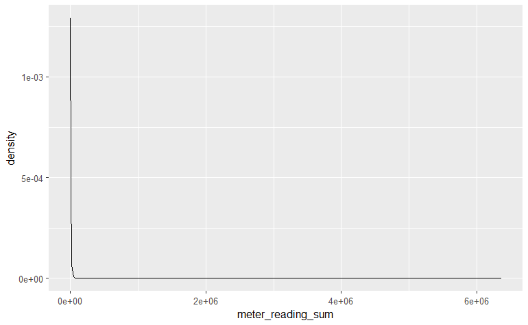

```r
ggplot2::ggplot(data = ff_train_agg, aes(x = meter_reading_sum)) +
  geom_density()
```

Resulting distribution is of the ‘power law’ type. It’s heavily biased to the left. It could be to some extent normalized by using ‘Log’ transformation. ‘+1’ is to avoid minus infinity when the log gets ‘0’ - prevents generation of NAs).

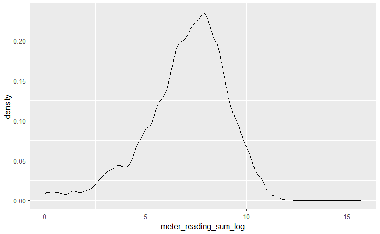

```r
# A new column
ff_train_agg$meter_reading_sum_log <- log(ff_train_agg$meter_reading_sum+1)
ggplot(data = ff_train_agg, aes(x = meter_reading_sum_log)) +
  geom_density()
```

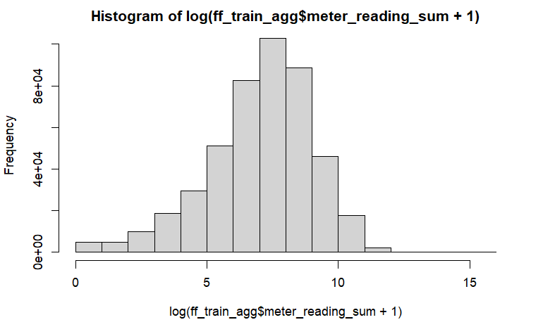

```r
hist(log(ff_train_agg$meter_reading_sum+1))
```

#### Outcome variable Vs categories of all categorical variables

make sure that excel file ‘cat_var_before_data_cleansing’ is updated.

```r
pdf("C:/Users/Avishai/Documents/General/Personal/DS Course/Google drive content/Projects/Final project-ASHRAE-Great Energy Predictor III/Graphs-before completion of data cleansing/meter_reading_sum_log_uni_graphs.pdf")

options(repr.plot.width = 8, repr.plot.height = 8)                        # graph size
par(mfrow=c(2,2))                                                         # number of rows and columns at the graph

# a csv file stores all the categorical variables - nominal and ordinal
cat_lst <- read.csv("C:/Users/Avishai/Documents/General/Personal/DS Course/Google drive content/Projects/Final project-ASHRAE-Great Energy Predictor III/csv files/cat_var_before_data_cleansing.csv")
prt_df <- ff_train_agg[is.na(ff_train_agg$meter_reading_sum_log) == F,]   # boxplot collapses when NUlls exist at the dependent variable
for (v in cat_lst$cat_variables) {
  boxplot(prt_df$meter_reading_sum_log ~ prt_df[[v]], main = v, cex.main = 0.85)
}
par(mfrow=c(1,1))                                                         # show it all at once

dev.off()
```

Variable that were found to be affect the outcome variable are: - ‘site_id’ - ‘sw_primary_use_Parking’ - ‘sw_primary_use_ReligiousWorship’ - ‘sw_primary_use_Utility’

```r
# Deleting the outcome_log column generated earlier
ff_train_agg$meter_reading_sum_log <- NULL
```

#### Visual determination - **boxplots**

‘boxplot’ function: ‘boxplot’ - describes the behavior of numeric variables’ distribution

```r
# Cyclical variables (contain "_x_" or "_y_")
cyclical_vars <- names(ff_train_agg)[grep("_x_|_y_|(_x$|_y$)", names(ff_train_agg))]

# variables that their value distributions have no meaning
exclude <- c(nominal, "date", cyclical_vars)
vars_for_boxplot <- setdiff(names(ff_train_agg), exclude)

pdf("C:/Users/Avishai/Documents/General/Personal/DS Course/Google drive content/Projects/Final project-ASHRAE-Great Energy Predictor III/Graphs-before completion of data cleansing/boxplot_uni_graphs.pdf")

options(repr.plot.width = 8, repr.plot.height = 8)     # graph size
par(mfrow=c(2,3))                                      # number of rows and columns at the graph

for(v in vars_for_boxplot) {
    boxplot(ff_train_agg[[v]], main = v, cex.main = 0.80)
}
par(mfrow=c(1,1))                                      # show it all at once

dev.off()
```

#### Visual determination - **scatter plots**

‘scatter plot’ - shows outliers of variables. Horizontal axis is an index.

```r
# For runtime considerations, a random sample of the data is taken:
set.seed(4)
sample_df <- ff_train_agg %>% slice_sample(n = 20000)
# n = 20000; running time 1 min

pdf("C:/Users/Avishai/Documents/General/Personal/DS Course/Google drive content/Projects/Final project-ASHRAE-Great Energy Predictor III/Graphs-before completion of data cleansing/scatter_uni_graphs.pdf")
options(repr.plot.width = 8, repr.plot.height = 8)
par(mfrow=c(2,3))

# 'date' - too many values that have no meaning at the graph
for(v in names(ff_train_agg)[!names(ff_train_agg) %in% "date"]) {
    # '+1' - as 'scatter.smooth' function can't receive zero at y axis, because of log scaling it uses
    # 'building_id' represented in the horizontal axis as an index
    scatter.smooth(as.numeric(sample_df[[v]]) + 1 ~ sample_df$building_id , main = v, ylab = v,
        family = "symmetric", lpars = list(col = "red", lwd = 2, lty = 2))
}
par(mfrow=c(1,1))

dev.off()
```

#### Missing Value Exploration

Stats that help understanding the amount of missing values:

```r
# Find columns with NAs
missingCols <- getMissingness(ff_train_agg, getRows = T)
```

```
[[1]]
                     var na.count rate
1            floor_count   442228 96.4
2             year_built   301358 65.7
3  wind_direction_x_mode      507  0.1
4  wind_direction_y_mode      507  0.1
5       precip_depth_sum       34  0.0
6       precip_depth_min       34  0.0
7       precip_depth_max       34  0.0
8        precip_depth_sd       34  0.0
9   air_temperature_mean       34  0.0
10   air_temperature_min       34  0.0

[[2]]
[1] "This dataset has 10714 (2.3%) complete rows. Original data has 458645 rows."
```

```r
missingCols$missingness
```

| var | na.count | rate |
| --- | --- | --- |
| floor_count | 442228 | 96.4 |
| year_built | 301358 | 65.7 |
| wind_direction_x_mode | 507 | 0.1 |
| wind_direction_y_mode | 507 | 0.1 |
| precip_depth_sum | 34 | 0.0 |
| precip_depth_min | 34 | 0.0 |
| precip_depth_max | 34 | 0.0 |
| precip_depth_sd | 34 | 0.0 |
| air_temperature_mean | 34 | 0.0 |
| air_temperature_min | 34 | 0.0 |

[output cut: 23 more lines]

```r
missingCols$message
```

```
[1] "This dataset has 10714 (2.3%) complete rows. Original data has 458645 rows."
```

A heatmap of the missing data:

‘vis_miss’ function:

```r
pdf("C:/Users/Avishai/Documents/General/Personal/DS Course/Google drive content/Projects/Final project-ASHRAE-Great Energy Predictor III/Graphs-before completion of data cleansing/Heatmap Missing Percentage Graph.pdf")
options(repr.plot.width = 25, repr.plot.height = 25)

# subset the data frame to include only the columns that have missing values
vis_miss(ff_train_agg[, missingCols$missingness$var], warn_large_data = FALSE) +
  theme(plot.title = element_text(size = 10),
        axis.text.x = element_text(size = 5, angle = 90),
        axis.title.y = element_blank())

dev.off()
```

Another visualization:

Converting ‘date’ variable’s data type from ‘date’ to ‘int’ as it can’t receive 0, 1 when it’s a ‘date’ data type, in the next chunk:

```r
ff_train_agg$date <- as.integer(ff_train_agg$date)
```

Following the factorizing operated earlier on ‘building_id’ column, it now can’t receive 0 or 1 for indicating its NA existence, as it doesn’t have 0 or 1 as categories. Therefore I will add to the column ‘0’ and ‘1’ as levels, just for that reason.

```r
pdf("C:/Users/Avishai/Documents/General/Personal/DS Course/Google drive content/Projects/Final project-ASHRAE-Great Energy Predictor III/Graphs-before completion of data cleansing/Missingness plot.pdf")

ff_train_agg_na <- ff_train_agg
levels(ff_train_agg_na$building_id) <- c(levels(ff_train_agg_na$building_id), 0, 1)

ff_train_agg_na[!is.na(ff_train_agg_na)] <- 0
ff_train_agg_na[is.na(ff_train_agg_na)] <- 1
gg_miss_var <- naniar::gg_miss_var(ff_train_agg_na)
gg_miss_var

dev.off()
```